# PHYS 210 Day 13 - Oct 20, 2025

Agenda:

1. Announcements
2. Today

## Due date mistake for today's artifact

1. The purpose was to have your early draft available to share now

## Coming up

1. This Wed (Oct 22): In-class project support
2. Next 1.5 weeks (Oct 27 - Nov 03) - 3 more lesson days
3. Project 03 starts: Nov 05

## Today - Peer feedback in groups of 3

Request the specific feedback you are looking for or use the peer feedback prompts document for suggestions

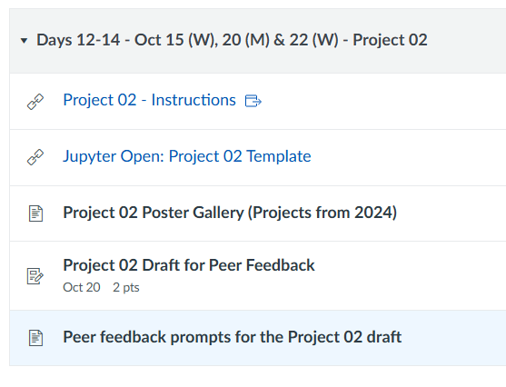

## Today - Engagement points

Once you have spent 15-20 minutes on feedback for each project

1. Add the name of our group member to the board
2. Include your table number to make it easier for us to find you

## 3 basic systems you can investigate

- **1 proton + 2 electrons orbiting in the same rotational directon:** Tricky to find interesting things to investigate - very sensitive to small asymmetries.
- **1 proton + 2 electrons orbiting in the opposite rotational directon:** Creates lots of different types of "orbits"
- **2 protons + 1 electron:** Largest number of different things to vary and still have stable orbits.

## You define stability

- It doesn't have to be identical repeating orbits. Many shapes precess
- It can be interesting to develelop indices or quality factors that characterize stability